# Material Progress and Social Well-being in Australia: A Comparative Assessment

A reproducible descriptive international comparison using the supplied OECD Current Well-being extract

Author

Haley Tran (530002284), Yilin Li (530536402), Winnie Qiu (550720773)

Published

July 22, 2026

## 1 Executive Summary

**Research question.** As Australia’s household income and employment improved, did lack of perceived social support and negative affect worsen relative to eligible supplied-country comparators?

Australia recorded substantial absolute material gains between 2010 and 2024: household income per person rose by USD 6,004 and employment by 4.82 percentage points. Among countries with the same observed endpoints, however, both changes were slightly below the median comparator change. Across the independent Gallup survey windows, lack of perceived social support rose from 4.93% in 2008–10 to 10.04% in 2023–25, and negative affect rose from 12.24% to 14.85%. Both social outcomes deteriorated more in Australia than the median eligible supplied-country comparator.

The evidence supports a descriptive material–social tension, not a causal claim. Bootstrap resampling of eligible countries leaves the adverse social gaps intact, whereas the relative income and employment gaps cross zero. Thus the social comparison is comparatively stable to comparator composition, while the material ranking is more sensitive. The analysis does not establish that material progress caused social deterioration, nor that two indicators exhaust the concepts of connection or well-being.

## 2 Research Question and Context

Income and employment are important measures of national progress, but they do not by themselves describe how people experience daily life. Material and lived-experience indicators can move in different directions, and a country can improve in absolute terms without improving faster than its peers. The supplied OECD Current Well-being extract allows this tension to be assessed using matched international reporting rather than an impressionistic comparison.

The question is relevant in the Australian context. The Australian Institute of Health and Welfare distinguishes social isolation from loneliness and reports both as forms of social disconnection with implications for well-being (Australian Institute of Health and Welfare 2026). This source provides context only: it uses a different construct and collection design from the OECD/Gallup lack-of-support measure. It neither independently validates the estimate nor identifies a cause.

The question is deliberately bounded: it tests a comparative descriptive pattern, not its causes or individual-level experience.

The analysis moves from comparative trajectories (Method 1), to matched endpoint changes (Method 2), comparator-composition sensitivity (Method 3), full-trajectory corroboration (Method 4), and finally secondary cross-country associations (Method 5).

## 3 Data Preparation and Comparability

The immutable input is the supplied `OECD Data.csv`: 8,806 country-indicator-year observations for 47 countries, 21 indicators and 10 domains. The audit preserves this raw file, standardises the fields needed for analysis, and stops if required values or unique country–indicator–year keys are absent. No row is interpolated, imputed, silently dropped or deduplicated by an arbitrary rule.

Cleaning also creates analytical metadata rather than merely changing formats. Each observation retains its country and indicator identifiers, unit, outcome direction and OECD status. The status is converted to an `is_flagged` field: 266 source observations are flagged for a time-series break, differing definition, estimate or provisional value. These observations are retained, not treated as missing; all Australian rows are normal, while peer flags remain visible for sensitivity checks. The full audit table and indicator caveats are provided in the Appendix audit traceability section.

Time is handled according to the source design. Household income and employment have 15 Australian annual observations from 2010 to 2024. Lack of social support and negative affect have six independent three-year Gallup windows; they are labelled by their full windows and never treated as annual series. The last social window is 2023–25, so it cannot isolate a single 2024 event. The audit records this distinction through an `independent_period` field, so repeated annual-looking Gallup rows are counted once per pooled window rather than as repeated independent evidence. Coverage and metadata outputs determined which outcomes could support a matched comparison; their details are in the Appendix A audit. Indicator constructs, units and pooling rules follow the supplied OECD definitions (Organisation for Economic Co-operation and Development 2026).

## 4 Outcome Selection and Exploratory Design

Exploratory coverage and construct checks fixed four primary outcomes before the common-endpoint analysis: household income per person (PPP), employment rate, lack of social support and negative affect. The first two represent material conditions; the latter two are focused measures of perceived social support and emotional well-being. Life satisfaction has only two Australian observations, and the health measures have limited common-endpoint coverage, so they are not primary long-run outcomes. The full inclusion rationale and secondary-indicator roles are documented in Appendix B.

All comparative claims use **eligible supplied-country comparators**: countries other than Australia that report the same indicator at Australia’s exact endpoints. The extract is not treated as an OECD membership ranking. Comparator counts differ across outcomes because coverage differs; this is reported rather than hidden behind a fixed-peer assumption.

The design separates absolute Australian change from comparative outperformance: a large Australian increase can coexist with a negative relative gap when the comparator median increases by more. It uses the median to reduce the influence of extreme country changes and retains native units so that USD and percentage-point outcomes are not treated as interchangeable.

The design also avoids treating data availability as evidence of national performance. A country absent from an endpoint comparison is not labelled as a poor performer; it is simply ineligible for that specific contrast. Similarly, the exploratory trajectory bands can change because reporting coverage changes. The primary comparison consequently depends only on the exact endpoint set, and the sensitivity analysis below tests how much the reported gap depends on that observed set. These decisions favour transparent, reproducible comparison over a broader but less defensible international ranking.

### 4.1 Method 1: Comparative Trajectory Exploration

For every observed period, Australia is plotted in native units against the median and interquartile range of countries reporting the same outcome in that period. Australia is excluded from these reference summaries. This visual analysis reveals direction, coverage and timing without a composite score or filled-in years. Because reporting countries can change across periods, it is an exploratory description rather than a fixed-panel estimate.

## 5 Analytical Methods

The executable analysis order and output provenance are listed in Appendix E.

### 5.1 Method 2: Primary Same-Endpoint Comparison

For each outcome, a country is eligible only if it reports both Australian endpoints. We first calculate each country’s observed change, then compare Australia’s change with the median change among its eligible comparators:

$$\Delta_c = y_{c,\mathrm{end}} - y_{c,\mathrm{start}},
\qquad
G = s\left[\Delta_{\mathrm{AUS}} -
\operatorname{median}(\Delta_c)\right].$$

Here, $s = 1$ for higher-is-better outcomes and $s = -1$ for lower-is-better outcomes. Thus, a positive $G$ always favours Australia while the reported changes retain their original units. The scorecard also reports Australia’s tie-aware favourable percentile—a relative position, not a probability or significance test.

Table 1: Method 2 primary scorecard; income is USD PPP and other outcomes are percentage points

| Outcome | AU change | Median change | Favourable gap | Favourable percentile | Comparators |
| --- | --- | --- | --- | --- | --- |
| Household income per person, PPP | 6,004.00 | 6,960.00 | -956.00 | 45.2 | 31 |
| Employment rate | 4.82 | 5.68 | -0.86 | 37.2 | 43 |
| Lack of social support | 5.12 | 0.83 | -4.29 | 8.7 | 46 |
| Negative affect | 2.61 | -0.05 | -2.66 | 19.6 | 46 |

### 5.2 Method 3: Comparator-Composition Bootstrap and Placebo Ranking

Method 3 holds Australia’s observed endpoint change fixed and resamples the exact eligible comparator countries with replacement 10,000 times. Every replicate recalculates the comparator median and favourable gap. Its interval is therefore a **comparator-composition sensitivity interval**, not survey-sampling uncertainty or a confidence interval for Australia’s change. Because the supplied countries are not a random sample, this asks only whether the sign changes when the observed comparator composition is perturbed. Crossing zero denotes composition sensitivity; remaining on one side supports stability within the eligible set, not causal or population inference. A complementary leave-one-country-out placebo ranking treats each eligible country as focal in turn and locates Australia in that distribution. It is not an independent significance test. Full bootstrap and placebo outputs are retained in Appendix C.

Table 2: Method 3 bootstrap sensitivity; values retain each outcome's native unit

| Outcome | Unit | Observed favourable gap | Bootstrap median [2.5%, 97.5%] | Favourable percentile | Comparators | Interpretation |
| --- | --- | --- | --- | --- | --- | --- |
| Households and NPISHs net adjusted disposable income per capita | US dollars per person, PPP converted | -956.00 | -956.00 [-2610.00, 1164.00] | 45.2 | 31 | comparator-sensitive |
| Employment rate | Percentage of population aged 25-64 years | -0.86 | -0.86 [-2.06, 0.17] | 37.2 | 43 | comparator-sensitive |
| Lack of social support | Percentage of population aged 15 years or over | -4.29 | -4.29 [-5.44, -2.79] | 8.7 | 46 | comparatively stable |
| Negative affect balance | Percentage of population aged 15 years or over | -2.66 | -2.66 [-3.77, -1.25] | 19.6 | 46 | comparatively stable |

### 5.3 Method 4: Robust Full-Trajectory Trends

Method 4 checks whether the primary endpoint directions agree with robust full-trajectory summaries. Direction-aware Theil–Sen slopes describe median pairwise change, while Kendall’s tau describes monotonic ordering. Material outcomes use 15 annual observations; only the social outcomes use six independent pooled windows. These diagnostics corroborate direction and comparative position; they are not causal estimates or definitive tests under temporal dependence. Full slope intervals, Kendall diagnostics and the fitted trajectory figure are provided in Appendix C.

### 5.4 Method 5: Exploratory Cross-Country Associations

Method 5 asks a different, secondary question: across countries, do stronger material improvements tend to rank alongside more favourable social change? Australia is excluded from estimation. Fixed common country panels, Spearman rank correlations, paired-country bootstraps, permutation p-values and Holm adjustment are used for the four pre-specified pairs. The analysis is ecological and exploratory, so it cannot identify a mechanism for Australia. Bootstrap intervals, fixed-panel and leave-one-out checks, and the diagnostic scatterplots are reported in Appendix D.

## 6 Results

### 6.1 Material conditions improved without comparative outperformance

Australia’s household income per person rose by USD 6,004 from 2010 to 2024. This is a substantial domestic gain, yet the median rise among 31 eligible supplied-country comparators was USD 6,960. The direction-aware gap was –USD 956 and Australia placed at the 45th favourable percentile. Employment also improved, by 4.82 percentage points, but the median change among 43 eligible comparators was 5.68 points. Its oriented gap was –0.86 points and its favourable percentile was 37th.

These results do not imply Australian material decline. They distinguish absolute improvement from comparative outperformance. In Method 3, both material intervals cross zero, so the precise relative ranking is sensitive to which eligible countries are resampled. Claims that Australia materially underperformed the entire reference population would exceed the evidence.

### 6.2 Social indicators deteriorated relative to comparators

Lack of perceived social support rose from 4.93% in 2008–10 to 10.04% in 2023–25: a 5.12-point adverse Australian change. The median eligible comparator worsened by 0.83 points. On the favourable scale, Australia’s gap was –4.29 points and its percentile was about 9th among 46 comparators. The bootstrap interval remained below zero, from –5.44 to –2.79 points.

Negative affect rose from 12.24% to 14.85%, an adverse change of 2.61 points. The median comparator changed by –0.05 points, leaving Australia’s favourable gap at –2.66 points and its percentile around 20th. Its bootstrap interval, –3.77 to –1.25 points, also remains adverse. These results refer to relative change in two reported measures; they are not prevalence estimates for all forms of loneliness, isolation or mental ill-health.

The trajectories in Figure 1 help separate a persistent pattern from a single endpoint comparison. Income and employment follow annual paths and show substantial Australian improvement, including short-term variation around the pandemic period. The social panels are intentionally sparser because each point is an independent pooled survey window. They show that the adverse social conclusion is not created by inventing annual values between windows. The most recent window matters: it contributes to the particularly low endpoint position for lack of social support. That is why the report presents both the endpoint result and the full-trajectory robustness check rather than treating a single latest value as decisive.

Figure 1 shows timing, native units and pooled-window structure; Figure 2 shows the fixed comparison rule and comparator-composition sensitivity. Together they present the progression from exploratory pattern to matched comparison and perturbation check.

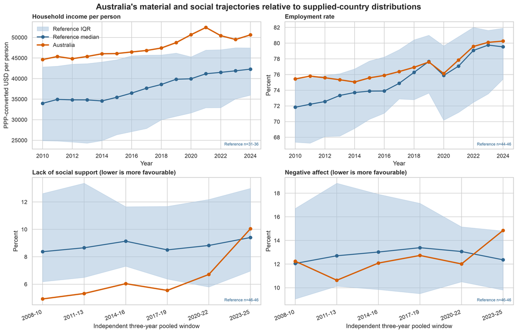

Figure 1: Australia (orange) and the same-period supplied-country median (blue); shaded bands show the interquartile range and reference counts exclude Australia. Income is PPP-converted USD per person. Lower social values are more favourable; social points are independent three-year pooled estimates and connecting lines are visual guides, not annual observations. The bands describe cross-country spread, not estimation uncertainty.

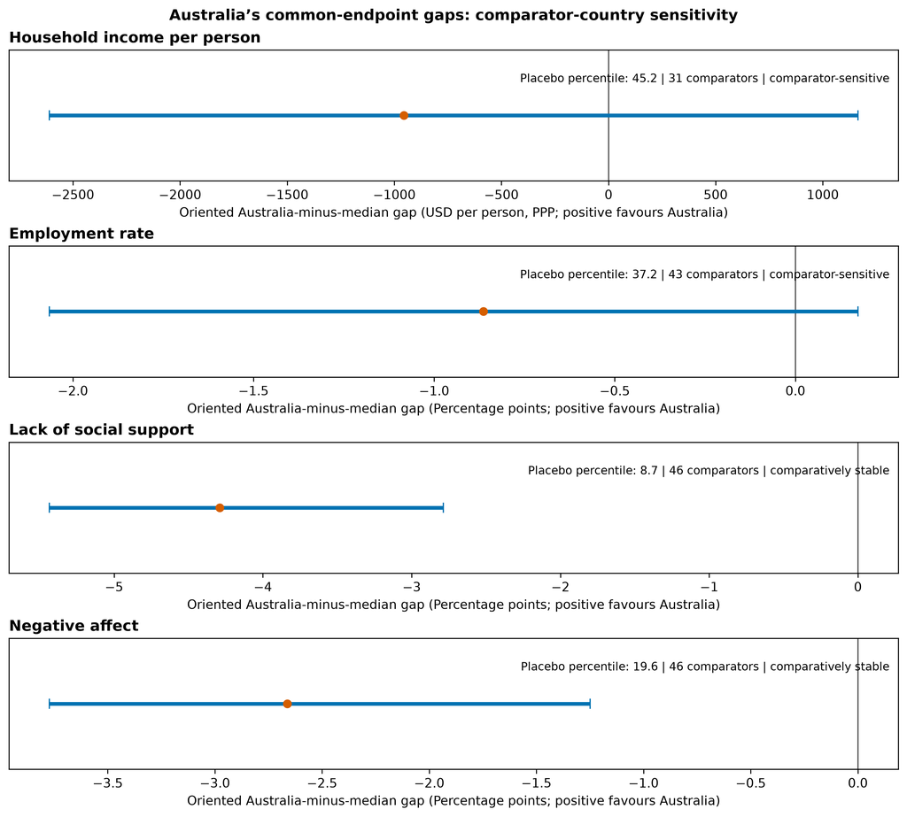

Figure 2: Method 3 same-endpoint gaps. Orange points are Australia’s observed direction-aware gaps and blue intervals show sensitivity to resampling eligible comparator countries. Positive values favour Australia; an interval crossing zero indicates that the comparative sign is composition-sensitive.

### 6.3 Method 4 robustness: full-trajectory directions agree

All four Theil–Sen slopes agree with the endpoint directions. In Figure 3, Australia’s favourable slope percentiles are 39th for income, 33rd for employment, 28th for social support and 24th for negative affect. This reduces dependence on endpoint choice, although negative affect’s weak monotonic ordering makes its trend a cautious directional check.

Table 3: Method 4 compact trend robustness scorecard

| Outcome | Native Theil–Sen slope | Favourable slope percentile | Endpoint agrees |
| --- | --- | --- | --- |
| Household income | +458 USD/year | 38.7 | Yes |
| Employment rate | +0.358 pp/year | 32.6 | Yes |
| Lack of social support | +0.186 pp/year | 28.3 | Yes |
| Negative affect | +0.174 pp/year | 23.9 | Yes |

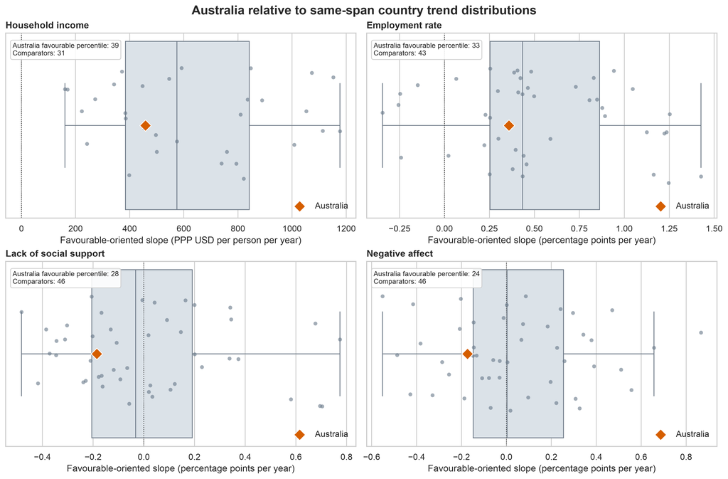

Figure 3: Australia’s favourable-oriented Theil–Sen slopes (orange diamonds) relative to eligible supplied countries with the required same-span coverage. Grey points are individual countries and boxes summarise their slope distributions; positive values indicate more favourable change. This is a full-trajectory comparative robustness check, not an uncertainty interval.

### 6.4 Method 5 associations provide context, not explanation

Positive rank associations were clearest for negative affect: income ($\rho=.496$, Holm-adjusted $p=.0156$) and employment ($\rho=.437$, Holm-adjusted $p=.0136$). Associations with social support did not survive multiplicity adjustment. These ecological patterns provide context but do not explain Australia’s result.

Table 4: Method 5 exploratory material–social rank associations

| Pair | Comparators | Spearman rho | Holm p |
| --- | --- | --- | --- |
| Income per person–lack of social support | 31 | 0.371 | 0.0819 |
| Income per person–negative affect | 31 | 0.496 | 0.0156 |
| Employment rate–lack of social support | 43 | 0.272 | 0.0819 |
| Employment rate–negative affect | 43 | 0.437 | 0.0136 |

### 6.5 Evidence synthesis: social deterioration is the more stable result

The comparative social conclusion is strongest: both outcomes deteriorate relative to eligible medians, their Method 3 intervals remain adverse, and Method 4 preserves the directions over the full trajectories. Material outcomes improved domestically, but their relative gaps are composition-sensitive. Method 5 supplies compatible cross-country context, not causal explanation. Methods 2–4 reuse the same observations, so their agreement is triangulation across analytical summaries rather than independent replication.

## 7 Discussion: Interpretation and Limits

The strongest supported statement is narrow: in the supplied extract, over the specified periods and with exact same-endpoint comparators, Australia’s material indicators improved while perceived lack of social support and negative affect worsened more than the typical eligible comparator. The social conclusion is stable to resampling the observed comparator set; the material relative ranking is not. The appropriate conclusion is a material–social tension, not a claim that material progress failed or that it caused the social outcomes.

Alternative explanations remain open. The final social window partly includes 2025 and pooled windows cannot reveal annual shocks. The OECD measure captures perceived availability of social support, not all social contact or loneliness. Country survey systems, definitions and observation-status flags differ, and eligible country sets vary by outcome. Income is PPP-adjusted household income per person, not household cash income or its distribution; employment does not measure job security or quality. More decisive explanation would require individual-level longitudinal data, compatible repeated surveys or a policy design that can test mechanisms and distributional heterogeneity. Indicator caveats and outcome boundaries are consolidated in Appendix A and Appendix B, respectively.

The analysis also conditions on countries observed at both endpoints. It cannot recover countries excluded by missing endpoints, test whether coverage is non-random, or propagate survey and measurement uncertainty in Australia’s estimates. Conclusions therefore generalise only to the eligible supplied-country sets.

## 8 Conclusion

On this bounded definition, Australia did well materially in absolute terms, but the supplied data do not support an equally favourable social assessment. Income and employment rose, but their relative gaps were comparator-sensitive. Across the available pooled survey windows, perceived lack of social support and negative affect worsened more than their eligible supplied-country comparator medians, with sensitivity intervals that remain adverse. This is reproducible descriptive evidence of a material–social tension in the supplied data. It is a strong prompt for further causal and distributional research, not a causal explanation itself.

## 9 Appendix

### 9.1 A. Data Audit and Comparability

The raw file is preserved without modification. The audit keeps identifiers, units, outcome direction, OECD status flags and independent-period labels alongside the observed values. The 2010–2024 processing scope contains 8,575 rows. It treats annual outcomes annually and collapses the 16 displayed Gallup rows to six independent pooled windows, with no interpolation. These are the implementation details supporting the cleaning claims in the main body.

Table 5: Reproducible data audit summary

| Check | Evidence | Status |
| --- | --- | --- |
| Raw input | 8,806 rows; 47 countries; 21 indicators | pass |
| Structure | Unique country–indicator–year keys and complete observed values | pass |
| Quality metadata | 266 flagged observations retained for sensitivity checks | recorded |
| Time handling | Annual and pooled Gallup series retained in their designed units | pass |

The audit writes `submission/data/oecd_clean.csv` and the following generated tables under `submission/report/tables/`: `time_series_gaps.csv`, `coverage_by_country_indicator.csv`, `coverage_by_country_year.csv`, `indicator_metadata.csv`, `same_year_australia_comparisons.csv`, `australia_indicator_summary.csv`, `domain_coverage_all.csv` and `domain_coverage_australia.csv`. Together they document coverage, units, direction, status flags and indicator-specific comparability caveats.

### 9.2 B. Outcome Selection and Secondary Indicators

The audit considered economics, health, social connections and subjective well-being. The primary outcomes were selected for temporal coverage, construct relevance and common-endpoint availability—not because they produced the largest apparent contrast. Secondary indicators remain useful context but are not allowed to alter the four-outcome primary conclusion.

| Candidate indicator or domain | Role in the report | Reason for treatment |
| --- | --- | --- |
| Household income and employment | Primary material outcomes | Annual Australian coverage and clear material interpretation |
| Lack of social support and negative affect | Primary social outcomes | Six aligned independent Gallup windows and broad international coverage |
| Long hours, gender wage gap and S80/S20 inequality | Secondary material context | Informative for job quality, gender disparity and distribution, but not part of the pre-specified four-outcome estimand |
| Life satisfaction | Excluded from long-run inference | Only two Australian observations |
| Health indicators | Context only | Life expectancy rose from 81.7 years in 2010 to 83.0 in 2023; the combined suicide/alcohol/drug measure has only 18 shared 2024 endpoints and combines distinct causes |

### 9.3 C. Full Robustness Diagnostics

The main text reports the key Method 3 conclusion. The tables below retain the full bootstrap and placebo information needed to reproduce its interpretation. The remaining Method 4 figure is a supporting diagnostic of the fitted Australian trajectories; the comparative slope-distribution figure appears in the main results because it directly shows Australia’s full-trajectory position among eligible comparators.

Table 6: Method 3 full comparator-composition bootstrap results

| Outcome | Unit | Period | Observed gap | Bootstrap median | 2.5% | 97.5% | Comparators | Replicates | Seed | Interpretation |
| --- | --- | --- | --- | --- | --- | --- | --- | --- | --- | --- |
| Households and NPISHs net adjusted disposable income per capita | US dollars per person, PPP converted | 2010–2024 | -956.000 | -956.000 | -2610.000 | 1164.000 | 31 | 10000 | 20260720 | comparator-sensitive |
| Employment rate | Percentage of population aged 25-64 years | 2010–2024 | -0.864 | -0.864 | -2.065 | 0.173 | 43 | 10000 | 20260720 | comparator-sensitive |
| Lack of social support | Percentage of population aged 15 years or over | 2008–10 to 2023–25 pooled windows | -4.291 | -4.291 | -5.435 | -2.788 | 46 | 10000 | 20260720 | comparatively stable |
| Negative affect balance | Percentage of population aged 15 years or over | 2008–10 to 2023–25 pooled windows | -2.662 | -2.662 | -3.772 | -1.250 | 46 | 10000 | 20260720 | comparatively stable |

Table 7: Method 3 leave-one-country-out placebo ranking

| Outcome | Australia placebo gap | Favourable percentile | More favourable countries | Less favourable countries | Ties |
| --- | --- | --- | --- | --- | --- |
| Households and NPISHs net adjusted disposable income per capita | -956.000 | 45.2 | 17 | 14 | 0 |
| Employment rate | -0.864 | 37.2 | 27 | 16 | 0 |
| Lack of social support | -4.291 | 8.7 | 42 | 4 | 0 |
| Negative affect balance | -2.662 | 19.6 | 37 | 9 | 0 |

Table 8: Method 4 full trend robustness results

| Outcome | Independent observations | Native slope | Slope CI low | Slope CI high | Favourable tau | Holm p | Comparators | Favourable slope percentile | Endpoint agrees |
| --- | --- | --- | --- | --- | --- | --- | --- | --- | --- |
| Household income | 15.000000 | 458.222 | 371.000 | 599.000 | 0.848 | 0.0000 | 31 | 38.7 | True |
| Employment rate | 15.000000 | 0.358 | 0.184 | 0.510 | 0.752 | 0.0001 | 43 | 32.6 | True |
| Lack of social support | 6.000000 | 0.186 | 0.038 | 0.749 | -0.867 | 0.0333 | 46 | 28.3 | True |
| Negative affect | 6.000000 | 0.174 | -0.239 | 0.485 | -0.333 | 0.4694 | 46 | 23.9 | True |

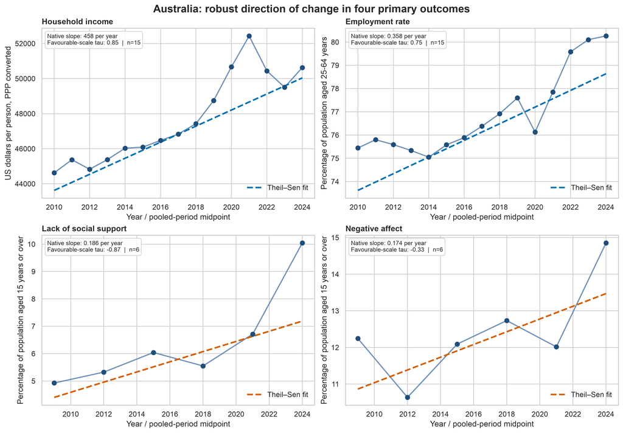

Figure 4: Australian observations and fitted Theil–Sen trends for the four primary outcomes. Material panels use 15 annual observations and social panels use six independent pooled windows; the fits summarise direction rather than causal effects.

### 9.4 D. Exploratory Association Diagnostics

Method 5 is retained as a diagnostic rather than an explanation of Australia’s outcome. The full table reports uncertainty, multiplicity adjustment and the fixed common-panel check; the scatterplot shows the underlying cross-country ecological relationship.

Table 9: Method 5 full exploratory association diagnostics

| Material outcome | Social outcome | Comparators | Spearman rho | Bootstrap 2.5% | Bootstrap 97.5% | Holm p | Fixed-panel n | Fixed-panel rho | Leave-one-out sign stable |
| --- | --- | --- | --- | --- | --- | --- | --- | --- | --- |
| Income per person | Lack of social support | 31 | 0.371 | 0.027 | 0.625 | 0.0819 | 31 | 0.371 | True |
| Income per person | Negative affect | 31 | 0.496 | 0.176 | 0.764 | 0.0156 | 31 | 0.496 | True |
| Employment rate | Lack of social support | 43 | 0.272 | -0.047 | 0.559 | 0.0819 | 31 | 0.283 | True |
| Employment rate | Negative affect | 43 | 0.437 | 0.171 | 0.645 | 0.0136 | 31 | 0.524 | True |

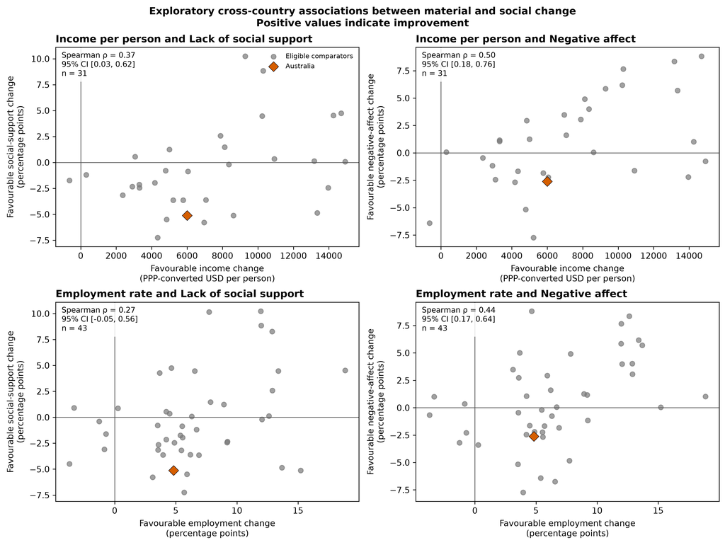

Figure 5: Exploratory cross-country material–social associations. Positive values indicate improvement. Australia is shown separately and excluded from the Spearman estimates, bootstrap intervals and permutation tests.

### 9.5 E. Reproduction Instructions and File Provenance

The analysis implementation is in notebooks. Execute them in the following order before rendering the report; each row identifies the files it generates or validates.

| Stage | Notebook or source | Generated or validated files | Purpose |
| --- | --- | --- | --- |
| Raw input | `submission/OECD Data.csv` | Immutable supplied input | Source data for every result |
| Audit and cleaning | `submission/code/data_audit.ipynb` | `submission/data/oecd_clean.csv`; audit/coverage tables listed above | Validates structure, preserves flags and labels independent periods |
| Exploration and principal trajectory | `submission/code/method1_eda.ipynb` | `material_social_trajectories.png`, `material_social_trajectory_coverage.csv`; coverage and same-year comparison evidence | Selects outcomes and exports Method 1 with traceable comparator counts |
| Primary same-endpoint comparison | `submission/code/method02_primary_same_endpoint.ipynb` | `material_social_primary_results.csv` | Method 2 |
| Comparator bootstrap and placebo ranking | `submission/code/method03_comparator_bootstrap_placebo.ipynb` | `material_social_bootstrap_results.csv`, `material_social_placebo_results.csv`, `material_social_comparative_gaps.png` | Method 3 |
| Visual review | `submission/code/final_visuals.ipynb` | Displays generated Method 3–5 assets without overwriting them | Consolidated visual inspection |
| Trend robustness | `submission/code/method4_theilsen_kendall.ipynb` | `material_social_trend_results.csv`, `method4_*.csv` and Method 4 figures | Method 4 |
| Exploratory association | `submission/code/method5_spearman_association.ipynb` | `material_social_spearman_results.csv`, `material_social_spearman_associations.png` | Method 5 |
| Report | `submission/report/australia_material_social_report.qmd` | `submission/report/australia_material_social_report.html` | Recreates the narrative, tables and figures |

The automated tests verify audit invariants, Method 1 coverage and deterministic seeded Method 3–5 outputs.

After extracting the archive, keep the folder name `submission` and run the complete workflow from inside it:

```bash
cd submission
python3 -m venv .venv
source .venv/bin/activate
python -m pip install -r requirements.txt
./run_all.sh
# macOS convenience command:
open report/australia_material_social_report.html
```

On Windows or Linux, open `report/australia_material_social_report.html` in a web browser using the normal file manager or browser command for that system.

The script regenerates all processed data, tables and figures, runs the tests and renders this report. From the parent directory containing `submission/`, the equivalent command is `./submission/run_all.sh`. Report-only regeneration from inside `submission/` uses `quarto render report/australia_material_social_report.qmd`.

## References

Australian Institute of Health and Welfare. 2026. “Social Isolation and Loneliness.” https://www.aihw.gov.au/mental-health/topic-areas/health-wellbeing/social-isolation-and-loneliness.

Organisation for Economic Co-operation and Development. 2026. *OECD How’s Life? Well-Being Database: Definitions and Metadata*. OECD.